# Assignment #2 - Meta-analysis on Ocean Ocidification

u7457373 Mingrui Sun

2022-10-30

Import some packages we need.

```r
library(tidyverse)
library(metafor)
library(orchaRd)
```

Load in Clark et al(2020) data.

```r
data <- read_csv("C:/Users/Administrator/Desktop/BIOL6207/OA_activitydat_20190302_BIOL3207.csv")
```

```
## * `` -> ...1
```

```r
data
```

```
## # A tibble: 589 x 9
##     ...1 loc       species treatment animal_id    sl size  activity comment
##    <dbl> <chr>     <chr>   <chr>         <dbl> <dbl> <chr>    <dbl> <chr>
##  1     1 LIRS 2014 ambon   CO2              64  57.0 big       8.15 27min means~
##  2     2 LIRS 2014 ambon   CO2              65  38.2 big      10.5  27min means~
##  3     3 LIRS 2014 ambon   CO2              67  39.3 big       6.51 27min means~
##  4     4 LIRS 2014 ambon   CO2              68  36.1 big      27.8  27min means~
##  5     5 LIRS 2014 lemon   CO2              74  36.4 big      36.7  27min means~
##  6     6 LIRS 2014 ambon   CO2              75  35.9 big      42.8  27min means~
##  7     7 LIRS 2014 lemon   CO2              81  35.7 big      21.9  27min means~
##  8     8 LIRS 2014 ambon   CO2              84  38.4 big      24.6  27min means~
##  9     9 LIRS 2014 ambon   CO2             222  34   big      NA    recording f~
## 10    10 LIRS 2014 ambon   CO2              85  48.3 big      35.1  27min means~
## # ... with 579 more rows
```

Transform column’s name of ‘data’ to the same as ‘ocean_meta_data.csv’.

```r
names(data)[3]='Species'
```

Remove some meaningless data with NA.

```r
data1<- data %>% filter(!(is.na(animal_id))) %>% filter(!(is.na(activity)))
data1
```

```
## # A tibble: 550 x 9
##     ...1 loc       Species treatment animal_id    sl size  activity comment
##    <dbl> <chr>     <chr>   <chr>         <dbl> <dbl> <chr>    <dbl> <chr>
##  1     1 LIRS 2014 ambon   CO2              64  57.0 big       8.15 27min means~
##  2     2 LIRS 2014 ambon   CO2              65  38.2 big      10.5  27min means~
##  3     3 LIRS 2014 ambon   CO2              67  39.3 big       6.51 27min means~
##  4     4 LIRS 2014 ambon   CO2              68  36.1 big      27.8  27min means~
##  5     5 LIRS 2014 lemon   CO2              74  36.4 big      36.7  27min means~
##  6     6 LIRS 2014 ambon   CO2              75  35.9 big      42.8  27min means~
##  7     7 LIRS 2014 lemon   CO2              81  35.7 big      21.9  27min means~
##  8     8 LIRS 2014 ambon   CO2              84  38.4 big      24.6  27min means~
##  9    10 LIRS 2014 ambon   CO2              85  48.3 big      35.1  27min means~
## 10    11 LIRS 2014 ambon   CO2              88  43.4 big       1.02 27min means~
## # ... with 540 more rows
```

Select data of ‘data1’ which treatment is ‘control’.

```r
data_control<- data1 %>% filter(data1$treatment=='control')
data_control
```

```
## # A tibble: 287 x 9
##     ...1 loc       Species treatment animal_id    sl size  activity comment
##    <dbl> <chr>     <chr>   <chr>         <dbl> <dbl> <chr>    <dbl> <chr>
##  1    40 LIRS 2014 lemon   control          51  36.0 big       4.68 27min means~
##  2    41 LIRS 2014 lemon   control         116  38.4 big       9.73 27min means~
##  3    42 LIRS 2014 lemon   control         122  38.3 big       2.61 27min means~
##  4    43 LIRS 2014 ambon   control         124  45.6 big      31.0  27min means~
##  5    44 LIRS 2014 ambon   control         125  37.5 big      20.1  27min means~
##  6    45 LIRS 2014 ambon   control         132  36.7 big       9.75 27min means~
##  7    46 LIRS 2014 ambon   control         133  43.4 big       7.88 27min means~
##  8    47 LIRS 2014 ambon   control         134  41.1 big       7.97 27min means~
##  9    48 LIRS 2014 ambon   control         140  62.6 big      12.8  27min means~
## 10    49 LIRS 2014 ambon   control         142  42.5 big      18.7  27min means~
## # ... with 277 more rows
```

Calculate n, mean and sd for each of the fish species’ average activity for control group.

```r
data2<-data_control %>% group_by(Species) %>% summarise(ctrl.n=n(),ctrl.mean=mean(activity),ctrl.sd=sd(activity), .groups = "drop")
data2
```

```
## # A tibble: 6 x 4
##   Species   ctrl.n ctrl.mean ctrl.sd
##   <chr>      <int>     <dbl>   <dbl>
## 1 acantho       90      28.9   11.2
## 2 ambon         21      17.3   11.5
## 3 chromis       20      26.1    9.13
## 4 humbug        65      34.9   13.9
## 5 lemon         30      19.8   12.3
## 6 whitedams     61      26.6   10.9
```

Select data of ‘data1’ which treatment is ‘CO2’.

```r
data_co2<- data1 %>% filter(data1$treatment=='CO2')
data_co2
```

```
## # A tibble: 263 x 9
##     ...1 loc       Species treatment animal_id    sl size  activity comment
##    <dbl> <chr>     <chr>   <chr>         <dbl> <dbl> <chr>    <dbl> <chr>
##  1     1 LIRS 2014 ambon   CO2              64  57.0 big       8.15 27min means~
##  2     2 LIRS 2014 ambon   CO2              65  38.2 big      10.5  27min means~
##  3     3 LIRS 2014 ambon   CO2              67  39.3 big       6.51 27min means~
##  4     4 LIRS 2014 ambon   CO2              68  36.1 big      27.8  27min means~
##  5     5 LIRS 2014 lemon   CO2              74  36.4 big      36.7  27min means~
##  6     6 LIRS 2014 ambon   CO2              75  35.9 big      42.8  27min means~
##  7     7 LIRS 2014 lemon   CO2              81  35.7 big      21.9  27min means~
##  8     8 LIRS 2014 ambon   CO2              84  38.4 big      24.6  27min means~
##  9    10 LIRS 2014 ambon   CO2              85  48.3 big      35.1  27min means~
## 10    11 LIRS 2014 ambon   CO2              88  43.4 big       1.02 27min means~
## # ... with 253 more rows
```

Calculate n, mean and sd for each of the fish species’ average activity for CO2 group.

```r
data3<-data_co2 %>% group_by(Species) %>% summarise(oa.n=n(),oa.mean=mean(activity),oa.sd=sd(activity), .groups = "drop")
data3
```

```
## # A tibble: 6 x 4
##   Species    oa.n oa.mean oa.sd
##   <chr>     <int>   <dbl> <dbl>
## 1 acantho      86    27.3 10.4
## 2 ambon        22    18.4 12.2
## 3 chromis      14    24.8 11.0
## 4 humbug       62    40.3 11.9
## 5 lemon        19    26.0 11.0
## 6 whitedams    60    24.5  9.95
```

Remove ‘Species’ column of ‘data3’.

```r
data4<- data3 %>% mutate(Species=NULL)
data4
```

```
## # A tibble: 6 x 3
##    oa.n oa.mean oa.sd
##   <int>   <dbl> <dbl>
## 1    86    27.3 10.4
## 2    22    18.4 12.2
## 3    14    24.8 11.0
## 4    62    40.3 11.9
## 5    19    26.0 11.0
## 6    60    24.5  9.95
```

Load in the data of ‘clark_paper_data.csv’.

```r
clark <- read_csv("C:/Users/Administrator/Desktop/BIOL6207/clark_paper_data.csv")
clark
```

```
## # A tibble: 1 x 15
##   Study Authors     `Year (online)` `Year (print)` Title   Journal `Pub year IF`
##   <chr> <chr>                 <dbl>          <dbl> <chr>   <chr>           <dbl>
## 1 a92   Clark et al            2020           2020 Ocean ~ Nature           69.5
## # ... with 8 more variables: 2017 IF <dbl>, Average n <dbl>, Effect type <chr>,
## #   Climate (FishBase) <chr>, Env cue/stimulus? <chr>, Cue/stimulus type <lgl>,
## #   Behavioural metric <chr>, Life stage <chr>
```

Load in the data of ‘ocean_meta_data.csv’.

```r
ocean <- read_csv("C:/Users/Administrator/Desktop/BIOL6207/ocean_meta_data.csv")
ocean
```

```
## # A tibble: 818 x 22
##    Study Authors      `Year (online)` `Year (print)` Title Journal `Pub year IF`
##    <chr> <chr>                  <dbl>          <dbl> <chr> <chr>   <chr>
##  1 a1    Munday et al            2009           2009 Ocea~ PNAS    9.432
##  2 a1    Munday et al            2009           2009 Ocea~ PNAS    9.432
##  3 a1    Munday et al            2009           2009 Ocea~ PNAS    9.432
##  4 a1    Munday et al            2009           2009 Ocea~ PNAS    9.432
##  5 a1    Munday et al            2009           2009 Ocea~ PNAS    9.432
##  6 a1    Munday et al            2009           2009 Ocea~ PNAS    9.432
##  7 a1    Munday et al            2009           2009 Ocea~ PNAS    9.432
##  8 a2    Dixson et al            2009           2010 Ocea~ Ecol L~ 10.318
##  9 a2    Dixson et al            2009           2010 Ocea~ Ecol L~ 10.318
## 10 a2    Dixson et al            2009           2010 Ocea~ Ecol L~ 10.318
## # ... with 808 more rows, and 15 more variables: 2017 IF <chr>,
## #   Average n <dbl>, Effect type <chr>, Species <chr>,
## #   Climate (FishBase) <chr>, Env cue/stimulus? <chr>, Cue/stimulus type <chr>,
## #   Behavioural metric <chr>, Life stage <chr>, ctrl.n <dbl>, ctrl.mean <dbl>,
## #   ctrl.sd <dbl>, oa.n <dbl>, oa.mean <dbl>, oa.sd <dbl>
```

Combine the data of ‘clark’, ‘data2’, ‘data4’ into one tibble.

```r
calls <- bind_cols(clark,data2,data4)
calls
```

```
## # A tibble: 6 x 22
##   Study Authors     `Year (online)` `Year (print)` Title   Journal `Pub year IF`
##   <chr> <chr>                 <dbl>          <dbl> <chr>   <chr>           <dbl>
## 1 a92   Clark et al            2020           2020 Ocean ~ Nature           69.5
## 2 a92   Clark et al            2020           2020 Ocean ~ Nature           69.5
## 3 a92   Clark et al            2020           2020 Ocean ~ Nature           69.5
## 4 a92   Clark et al            2020           2020 Ocean ~ Nature           69.5
## 5 a92   Clark et al            2020           2020 Ocean ~ Nature           69.5
## 6 a92   Clark et al            2020           2020 Ocean ~ Nature           69.5
## # ... with 15 more variables: 2017 IF <dbl>, Average n <dbl>,
## #   Effect type <chr>, Climate (FishBase) <chr>, Env cue/stimulus? <chr>,
## #   Cue/stimulus type <lgl>, Behavioural metric <chr>, Life stage <chr>,
## #   Species <chr>, ctrl.n <int>, ctrl.mean <dbl>, ctrl.sd <dbl>, oa.n <int>,
## #   oa.mean <dbl>, oa.sd <dbl>
```

Transform columns’ rank of calls make sure they are same as ‘ocean_meta_data.csv’.

```r
calls1<- calls[,c(1,2,3,4,5,6,7,8,9,10,16,11,12,13,14,15,17,18,19,20,21,22)]
calls1
```

```
## # A tibble: 6 x 22
##   Study Authors     `Year (online)` `Year (print)` Title   Journal `Pub year IF`
##   <chr> <chr>                 <dbl>          <dbl> <chr>   <chr>           <dbl>
## 1 a92   Clark et al            2020           2020 Ocean ~ Nature           69.5
## 2 a92   Clark et al            2020           2020 Ocean ~ Nature           69.5
## 3 a92   Clark et al            2020           2020 Ocean ~ Nature           69.5
## 4 a92   Clark et al            2020           2020 Ocean ~ Nature           69.5
## 5 a92   Clark et al            2020           2020 Ocean ~ Nature           69.5
## 6 a92   Clark et al            2020           2020 Ocean ~ Nature           69.5
## # ... with 15 more variables: 2017 IF <dbl>, Average n <dbl>,
## #   Effect type <chr>, Species <chr>, Climate (FishBase) <chr>,
## #   Env cue/stimulus? <chr>, Cue/stimulus type <lgl>, Behavioural metric <chr>,
## #   Life stage <chr>, ctrl.n <int>, ctrl.mean <dbl>, ctrl.sd <dbl>, oa.n <int>,
## #   oa.mean <dbl>, oa.sd <dbl>
```

Transform columns’ value types of calls1 make sure they are same as ‘ocean_meta_data.csv’.

```r
calls2<- calls1 %>% mutate(`Pub year IF`=as.character(`Pub year IF`)) %>% mutate(`2017 IF`=as.character(`2017 IF`)) %>% mutate(`Cue/stimulus type`=as.character(`Cue/stimulus type`)) %>% mutate(ctrl.n=as.double(ctrl.n)) %>% mutate(oa.n=as.double(oa.n))
calls2
```

```
## # A tibble: 6 x 22
##   Study Authors     `Year (online)` `Year (print)` Title   Journal `Pub year IF`
##   <chr> <chr>                 <dbl>          <dbl> <chr>   <chr>   <chr>
## 1 a92   Clark et al            2020           2020 Ocean ~ Nature  69.5
## 2 a92   Clark et al            2020           2020 Ocean ~ Nature  69.5
## 3 a92   Clark et al            2020           2020 Ocean ~ Nature  69.5
## 4 a92   Clark et al            2020           2020 Ocean ~ Nature  69.5
## 5 a92   Clark et al            2020           2020 Ocean ~ Nature  69.5
## 6 a92   Clark et al            2020           2020 Ocean ~ Nature  69.5
## # ... with 15 more variables: 2017 IF <chr>, Average n <dbl>,
## #   Effect type <chr>, Species <chr>, Climate (FishBase) <chr>,
## #   Env cue/stimulus? <chr>, Cue/stimulus type <chr>, Behavioural metric <chr>,
## #   Life stage <chr>, ctrl.n <dbl>, ctrl.mean <dbl>, ctrl.sd <dbl>, oa.n <dbl>,
## #   oa.mean <dbl>, oa.sd <dbl>
```

Combine the data of ‘ocean’ and ‘calls2’ into one tibble.

```r
total <- bind_rows(ocean,calls2)
total
```

```
## # A tibble: 824 x 22
##    Study Authors      `Year (online)` `Year (print)` Title Journal `Pub year IF`
##    <chr> <chr>                  <dbl>          <dbl> <chr> <chr>   <chr>
##  1 a1    Munday et al            2009           2009 Ocea~ PNAS    9.432
##  2 a1    Munday et al            2009           2009 Ocea~ PNAS    9.432
##  3 a1    Munday et al            2009           2009 Ocea~ PNAS    9.432
##  4 a1    Munday et al            2009           2009 Ocea~ PNAS    9.432
##  5 a1    Munday et al            2009           2009 Ocea~ PNAS    9.432
##  6 a1    Munday et al            2009           2009 Ocea~ PNAS    9.432
##  7 a1    Munday et al            2009           2009 Ocea~ PNAS    9.432
##  8 a2    Dixson et al            2009           2010 Ocea~ Ecol L~ 10.318
##  9 a2    Dixson et al            2009           2010 Ocea~ Ecol L~ 10.318
## 10 a2    Dixson et al            2009           2010 Ocea~ Ecol L~ 10.318
## # ... with 814 more rows, and 15 more variables: 2017 IF <chr>,
## #   Average n <dbl>, Effect type <chr>, Species <chr>,
## #   Climate (FishBase) <chr>, Env cue/stimulus? <chr>, Cue/stimulus type <chr>,
## #   Behavioural metric <chr>, Life stage <chr>, ctrl.n <dbl>, ctrl.mean <dbl>,
## #   ctrl.sd <dbl>, oa.n <dbl>, oa.mean <dbl>, oa.sd <dbl>
```

Calculate the log response ratio (lnRR) effect size for every row and make a tibble for them.

```r
Study<-c()
Species<-c()
n1<-c()
n2<-c()
m1<-c()
m2<-c()
sd1<-c()
sd2<-c()
ir<-data.frame(Study <-c(Study,total$Study),
           Species<-c(Species,total$Species),
        n1<-c(total$ctrl.n),
n2<-c(total$oa.n),
m1<-c(abs(total$ctrl.mean)),
m2<-c(abs(total$oa.mean)),
sd1<-c(total$ctrl.sd),
sd2<-c(total$oa.sd))
`Year (online)`<-c(total$`Year (online)`)
dat<- escalc(measure='ROM',m1i=m1, m2i=m2, n1i=n1, n2i=n2, sd1i=sd1, sd2i= sd2,data=ir)
dat1<-data.frame(dat$Study....c.Study..total.Study.,dat$Species....c.Species..total.Species.,dat$yi,dat$vi,dat$sd1....c.total.ctrl.sd.,dat$sd2....c.total.oa.sd.,total$`Year (online)`)
dat1
```

[output not shown]

[output cut: 2460 more lines]

Make a meta-analytic model controls for the sampling variance of lnRR including a random effect of study.

```r
rma<-rma.mv(yi,vi,random =~1 | Study,data=dat)
rma
```

```
##
## Multivariate Meta-Analysis Model (k = 824; method: REML)
##
## Variance Components:
##
##             estim    sqrt  nlvls  fixed  factor
## sigma^2    2.0052  1.4160     92     no   Study
##
## Test for Heterogeneity:
## Q(df = 823) = 736089124.7778, p-val < .0001
##
## Model Results:
##
## estimate      se    zval    pval    ci.lb   ci.ub
##   0.0269  0.1488  0.1805  0.8568  -0.2648  0.3185
##
## ---
## Signif. codes:  0 '***' 0.001 '**' 0.01 '*' 0.05 '.' 0.1 ' ' 1
```

```r
predict(rma, transf = "transf.rom")
```

```
##
##    pred     se   ci.lb  ci.ub   pi.lb  pi.ub
##  0.0269 0.1488 -0.2648 0.3185 -2.7638 2.8175
```

[figure not shown]

```r
forest(dat$yi,dat$vi,col = 'red')
```

Make a funnel plot for visually showing the possibility of publication bias.

[figure not shown]

```r
metafor::funnel(x = rma, yaxis = "seinv",
    digits = 2, level = 0.05,
    las = 1, atransf = tanh, legend = TRUE)
```

Make a time-lag plot showing how effect sizes changed through time.

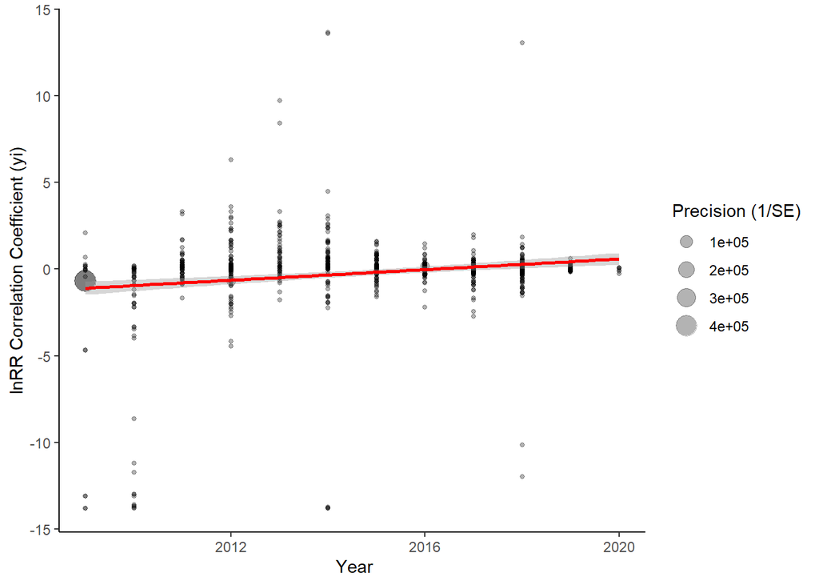

```r
ggplot(dat1, aes(y = dat1$dat.yi, x = dat1$total..Year..online.., size = 1/sqrt(dat1$dat.vi))) + geom_point(alpha = 0.3) +
    geom_smooth(method = lm, col = "red", show.legend = FALSE) + labs(x = " Year",
    y = "lnRR Correlation Coefficient (yi)", size = "Precision (1/SE)") +
    theme_classic()
```

From the figure, we can find that with time goes by, lnRR Correlation Coefficient seems to become a little higher.

Make a formal meta-regression model to test for time-lag bias.

```r
metareg_year <- rma.mv(dat1$dat.yi ~ dat1$total..Year..online.., V = dat1$dat.vi, random = ~1 | Species,
    test = "t", dfs = "contain", data = dat1)
summary(metareg_year)
```

```
##
## Multivariate Meta-Analysis Model (k = 824; method: REML)
##
##        logLik       Deviance            AIC            BIC           AICc
## -5386581.6373  10773163.2746  10773169.2746  10773183.4099  10773169.3040
##
## Variance Components:
##
##             estim    sqrt  nlvls  fixed   factor
## sigma^2    1.1824  1.0874     62     no  Species
##
## Test for Residual Heterogeneity:
## QE(df = 822) = 128790545.2367, p-val < .0001
##
## Test of Moderators (coefficient 2):
## F(df1 = 1, df2 = 822) = 1002.8490, p-val < .0001
##
## Model Results:
##
##                             estimate      se      tval   df    pval     ci.lb
## intrcpt                     -76.1145  2.4093  -31.5926   60  <.0001  -80.9337
## dat1$total..Year..online..    0.0378  0.0012   31.6678  822  <.0001    0.0354
##                                ci.ub
## intrcpt                     -71.2953  ***
## dat1$total..Year..online..    0.0401  ***
##
## ---
## Signif. codes:  0 '***' 0.001 '**' 0.01 '*' 0.05 '.' 0.1 ' ' 1
```

```r
r2_time <- orchaRd::r2_ml(metareg_year)
r2_time
```

```
##    R2_marginal R2_conditional
##    0.009512567    0.009512567
```

Make a formal meta-regression model to test for file-drawer bias.

```r
metareg_inverse <- rma.mv(dat1$dat.yi ~ 1/dat1$dat.vi, V = dat1$dat.vi, random = ~1 | Study,
    test = "t", dfs = "contain", data = dat1)
summary(metareg_inverse)
```

```
##
## Multivariate Meta-Analysis Model (k = 824; method: REML)
##
##        logLik       Deviance            AIC            BIC           AICc
## -5376318.3505  10752636.7009  10752640.7009  10752650.1268  10752640.7156
##
## Variance Components:
##
##             estim    sqrt  nlvls  fixed  factor
## sigma^2    2.0052  1.4160     92     no   Study
##
## Test for Heterogeneity:
## Q(df = 823) = 736089124.7778, p-val < .0001
##
## Model Results:
##
## estimate      se    tval  df    pval    ci.lb   ci.ub
##   0.0269  0.1488  0.1805  91  0.8572  -0.2687  0.3224
##
## ---
## Signif. codes:  0 '***' 0.001 '**' 0.01 '*' 0.05 '.' 0.1 ' ' 1
```

```r
r2_inverse <- orchaRd::r2_ml(metareg_inverse)
r2_inverse
```

```
##    R2_marginal R2_conditional
##              0              0
```

1. Authors should report exact sample sizes clearly in the text of manuscripts.
2. Studies with higher sample sizes should be published alongside, if not very soon after, an original novel finding to ensure that such a finding is robust.
3. Journals adopt the practice of registered reports to ensure that studies not detecting an effect are published in a timely manner.
4. Researchers should also seek, develop, and adhere to best practice guidelines for experimental setups [34] to minimize the potential for experimental artifacts to influence results.
5. Being critical and skeptical of early findings with large effects can help avoid many of the real-world problems associated with inflated effects.